# Preparing and Organizing Data for Display

Mahbubul Majumder, PhD  
Feb 27, 2019

### About data

- What is data?
  - fact or information about some population
- Types: mainly three types of data
  - Numerical/quantitative
    - Continuous: life time, income, distance etc.
    - Discrete: count data, number of accidents
  - Categorical/qualitative
    - ordered: income level (low, medium, high)
    - unordered: gender (male, female)
  - Dates

### Organizing data

- Can we always plot the data without reorganizing it?
- There are three types of reorganizations
  - tidy data
  - reshape the data
  - transform the data
- When data is received, the first step is to check if it violates the basic principles of tidy data.
- Reshaping the data is needed when we want to map the variable to an aesthetic but variable is not explicitly available
- Transforming is needed when some theoretical/ mathematical model is fitted or associated with the data

### Messy or untidy data

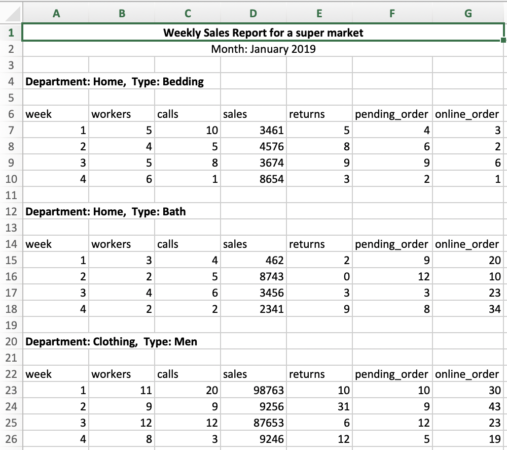

### Tidy data

| department | type | week | workers | calls | sales | returns | pending_order | online_order |
| --- | --- | --- | --- | --- | --- | --- | --- | --- |
| home | bedding | 1 | 5 | 10 | 3461 | 5 | 4 | 3 |
| home | bedding | 2 | 4 | 5 | 4576 | 8 | 6 | 2 |
| home | bedding | 3 | 5 | 8 | 3674 | 9 | 9 | 6 |
| home | bedding | 4 | 6 | 1 | 8654 | 3 | 2 | 1 |
| home | Bath | 1 | 3 | 4 | 462 | 2 | 9 | 20 |
| home | Bath | 2 | 2 | 5 | 8743 | 0 | 12 | 10 |
| home | Bath | 3 | 4 | 6 | 3456 | 3 | 3 | 23 |
| home | Bath | 4 | 2 | 2 | 2341 | 9 | 8 | 34 |
| clothing | Men | 1 | 11 | 20 | 98763 | 10 | 10 | 30 |
| clothing | Men | 2 | 9 | 9 | 9256 | 31 | 9 | 43 |
| clothing | Men | 3 | 12 | 12 | 87653 | 6 | 12 | 23 |
| clothing | Men | 4 | 8 | 3 | 9246 | 12 | 5 | 19 |
| clothing | Women | 1 | 9 | 10 | 5467 | 20 | 5 | 10 |
| clothing | Women | 2 | 7 | 8 | 4578 | 35 | 4 | 23 |
| clothing | Women | 3 | 9 | 11 | 3985 | 10 | 7 | 21 |
| clothing | Women | 4 | 6 | 4 | 3459 | 26 | 9 | 15 |

### Plotting Tidy data

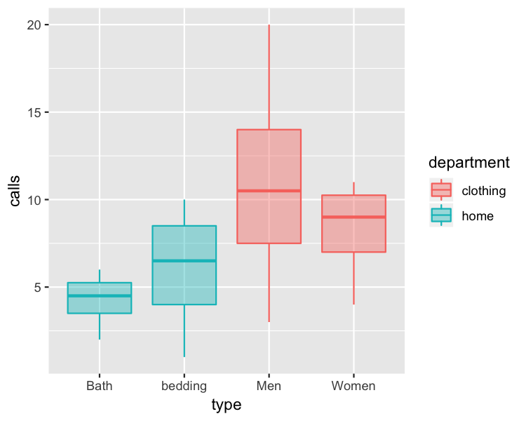

```r
ggplot(tidyDat, aes(x = type, y = calls, color = department,
                fill = department)) +
  geom_boxplot(alpha = 0.4)
```

### Tidy text data

- Data in texts
  - At 10am we had 40ml of water, 5 lb of meat, 3lb of salt and 20 apples
  - At 11am we had 25ml of water, 3 lb of meat, 2.5lb of salt and 11 apples
  - At 2pm we had 20ml of water, 3 lb of meat, 2lb of salt and 5 apples
- Tidy data

[output not shown]

- Other applications
  - Doctor's prescriptions
  - twitter or other social media

### Data in wide form

- What are the variables in the table shown below?

| year | online-sale | store-sale |
| --- | --- | --- |
| 2010 | 20 | 25 |
| 2011 | 24 | 31 |
| 2012 | 35 | 40 |

- This table is called the **wide form** table
- Are the variables in the table same as the variables in the plot?

```r
ggplot(dat, aes(year, sales, color=type)) +
  geom_line(size=1.1) + scale_color_discrete(name="Sale type")
```

- What are the variables in the data that produces the plot below?

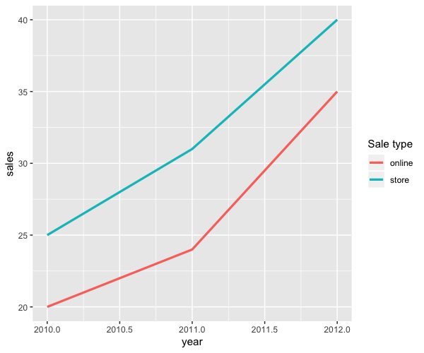

### Data in long form

- What are the variables in the table shown below?

| year | sales | type |
| --- | --- | --- |
| 2010 | 20 | online |
| 2011 | 24 | online |
| 2012 | 35 | online |
| 2010 | 25 | store |
| 2011 | 31 | store |
| 2012 | 40 | store |

- This table is called the **long form** table
- Are the variables in the table same as the variables in the plot?
- What are the variables in the data that produces the plot below?

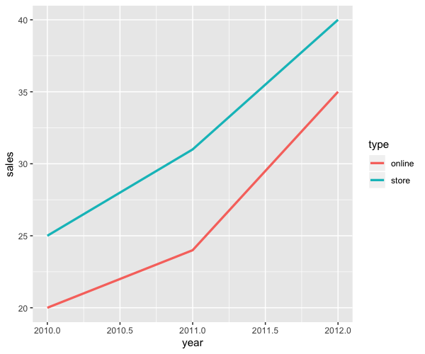

### Long vs wide form data

- How can we switch between long form and wide form of data
  - `install.packages(rehsape2)`
  - there are two functions
    - `melt()` melts data to long form
    - `dcast()` shapes molten data to wide form
- `cast()` function has some other variations
  - `acast()` is for array type data
  - `dcast()` is for data frame
- Package `tidyr` provides two functions to reshape data
  - `spread()` converts long form to wide form
  - `gather()` converts wide form to long form

### Long vs wide form data

- Converting wide to long form

```r
mdat <- melt(wdat,
             id = "year")
kable(mdat)
```

| year | variable | value |
| --- | --- | --- |
| 2010 | online-sale | 20 |
| 2011 | online-sale | 24 |
| 2012 | online-sale | 35 |
| 2010 | store-sale | 25 |
| 2011 | store-sale | 31 |
| 2012 | store-sale | 40 |

- Converting long to wide form

```r
wdat <- dcast(mdat,
          year~variable,
          value.var = "value")
kable(wdat)
```

| year | online-sale | store-sale |
| --- | --- | --- |
| 2010 | 20 | 25 |
| 2011 | 24 | 31 |
| 2012 | 35 | 40 |

### French fries data

- Some data from `R` data frame `french_fries`

|  | time | treatment | subject | rep | potato | buttery | grassy | rancid | painty |
| --- | --- | --- | --- | --- | --- | --- | --- | --- | --- |
| 61 | 1 | 1 | 3 | 1 | 2.9 | 0.0 | 0.0 | 0.0 | 5.5 |
| 25 | 1 | 1 | 3 | 2 | 14.0 | 0.0 | 0.0 | 1.1 | 0.0 |
| 62 | 1 | 1 | 10 | 1 | 11.0 | 6.4 | 0.0 | 0.0 | 0.0 |
| 26 | 1 | 1 | 10 | 2 | 9.9 | 5.9 | 2.9 | 2.2 | 0.0 |
| 63 | 1 | 1 | 15 | 1 | 1.2 | 0.1 | 0.0 | 1.1 | 5.1 |
| 27 | 1 | 1 | 15 | 2 | 8.8 | 3.0 | 3.6 | 1.5 | 2.3 |

- How many variables does this table show? How many actual variables does it have?
- Variable attributes are
  - 3 different oils (treatment)
  - 12 subjects
  - 10 different days (time)
  - 2 different fryers (rep)
  - 5 sensory attributes such as potato, buttery etc.

### French fries data

- Some data from `R` data frame `french_fries`

|  | time | treatment | subject | rep | potato | buttery | grassy | rancid | painty |
| --- | --- | --- | --- | --- | --- | --- | --- | --- | --- |
| 61 | 1 | 1 | 3 | 1 | 2.9 | 0.0 | 0.0 | 0.0 | 5.5 |
| 25 | 1 | 1 | 3 | 2 | 14.0 | 0.0 | 0.0 | 1.1 | 0.0 |
| 62 | 1 | 1 | 10 | 1 | 11.0 | 6.4 | 0.0 | 0.0 | 0.0 |
| 26 | 1 | 1 | 10 | 2 | 9.9 | 5.9 | 2.9 | 2.2 | 0.0 |
| 63 | 1 | 1 | 15 | 1 | 1.2 | 0.1 | 0.0 | 1.1 | 5.1 |
| 27 | 1 | 1 | 15 | 2 | 8.8 | 3.0 | 3.6 | 1.5 | 2.3 |

- How can we visualize the relationships between replication 1 and 2 for each of the sensory attributes?
- Discuss with your neighbor and prepare a plan.

### French fries data

- Some data from `R` data frame `french_fries`

|  | time | treatment | subject | rep | potato | buttery | grassy | rancid | painty |
| --- | --- | --- | --- | --- | --- | --- | --- | --- | --- |
| 61 | 1 | 1 | 3 | 1 | 2.9 | 0.0 | 0.0 | 0.0 | 5.5 |
| 25 | 1 | 1 | 3 | 2 | 14.0 | 0.0 | 0.0 | 1.1 | 0.0 |
| 62 | 1 | 1 | 10 | 1 | 11.0 | 6.4 | 0.0 | 0.0 | 0.0 |
| 26 | 1 | 1 | 10 | 2 | 9.9 | 5.9 | 2.9 | 2.2 | 0.0 |
| 63 | 1 | 1 | 15 | 1 | 1.2 | 0.1 | 0.0 | 1.1 | 5.1 |
| 27 | 1 | 1 | 15 | 2 | 8.8 | 3.0 | 3.6 | 1.5 | 2.3 |

- How can we visualize the relationships between replication 1 and 2 for each of the sensory attributes?
- Discuss with your neighbor and prepare a plan.
- Solution: generate scatterplot of rep1 vs rep2
  - we need to melt the data
  - we should not melt column time, treatment, subject and rep
  - finally cast the data as the form we want to create scatterplot

### Molten French fries data

- first we melt the french_fries data

```r
molten_fries <- melt(french_fries, id=1:4)
head(molten_fries)
```

```
  time treatment subject rep variable value
1    1         1       3   1   potato   2.9
2    1         1       3   2   potato  14.0
3    1         1      10   1   potato  11.0
4    1         1      10   2   potato   9.9
5    1         1      15   1   potato   1.2
6    1         1      15   2   potato   8.8
```

- now we need two variables rep1 and rep2 for the scatterplot
  - we can do this by casting this molten data
  - while casting we need to keep variables time treatment subject intact and fixed

### Casting French fries data

- we used formula `time + treatment + subject + variable~rep`
  - it allows us to fix variables time, treatment, subject and variable
  - it creates two new columns 1 and 2

```r
cast_fries <- dcast(molten_fries, time + treatment + subject + variable~rep, mean, value.var="value", na.rm=TRUE)
head(cast_fries)
```

```
  time treatment subject variable    1    2
1    1         1       3   potato  2.9 14.0
2    1         1       3  buttery  0.0  0.0
3    1         1       3   grassy  0.0  0.0
4    1         1       3   rancid  0.0  1.1
5    1         1       3   painty  5.5  0.0
6    1         1      10   potato 11.0  9.9
```

### Casting French fries data

- we rename those new columns to be rep1 and rep2

```r
colnames(cast_fries) <- c("time", "treatment", "subject" , "variable", "rep1","rep2")
head(cast_fries)
```

```
  time treatment subject variable rep1 rep2
1    1         1       3   potato  2.9 14.0
2    1         1       3  buttery  0.0  0.0
3    1         1       3   grassy  0.0  0.0
4    1         1       3   rancid  0.0  1.1
5    1         1       3   painty  5.5  0.0
6    1         1      10   potato 11.0  9.9
```

- now the data is ready to be plotted

### Plotting French fries data

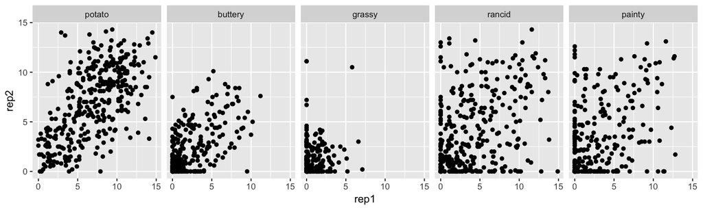

```r
ggplot(cast_fries, aes(rep1, rep2)) +
  geom_point() +
  facet_wrap(~variable, nrow=1)
```

- The correlation looks strong for potatoey and buttery, and poor for rancid and painty

### Plotting French fries data

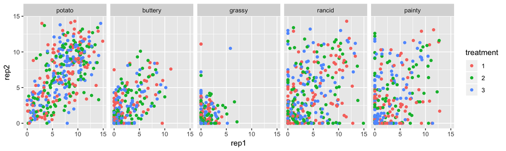

```r
ggplot(cast_fries, aes(rep1, rep2, color=treatment)) +
  geom_point() +
  facet_wrap(~variable, nrow=1)
```

- Similar behavior is observed for each treatment

### Aggregating data

Aggregation can be done using any function

**Note:** The function may return more than one row

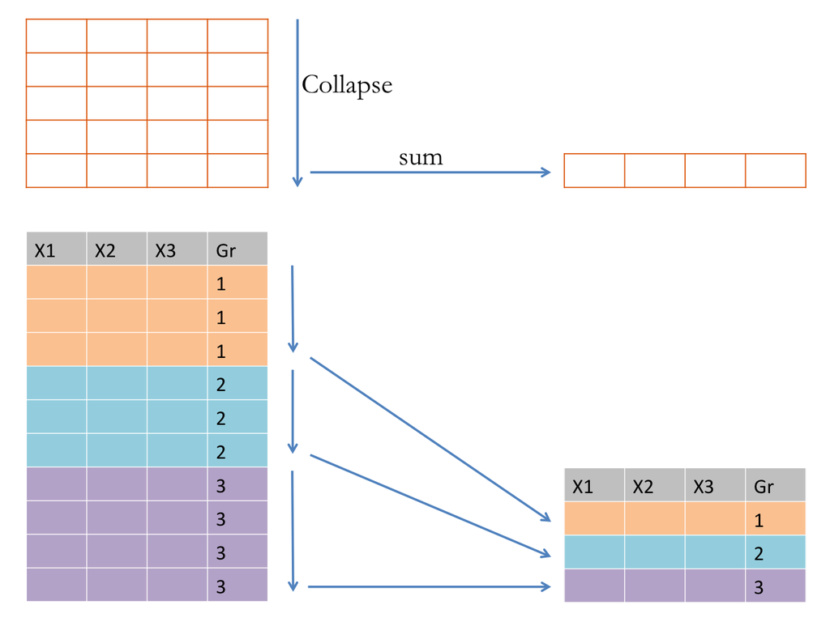

### Aggregating data

| department | type | calls |
| --- | --- | --- |
| home | bedding | 10 |
| home | bedding | 5 |
| home | bedding | 8 |
| home | bedding | 1 |
| home | Bath | 4 |
| home | Bath | 5 |
| home | Bath | 6 |
| home | Bath | 2 |
| clothing | Men | 20 |
| clothing | Men | 9 |
| clothing | Men | 12 |
| clothing | Men | 3 |
| clothing | Women | 10 |
| clothing | Women | 8 |
| clothing | Women | 11 |
| clothing | Women | 4 |

```r
library(dplyr)
avgCalls <- tidyDat %>%
  group_by(department, type) %>%
  summarise( calls = mean(calls))
kable(avgCalls)
```

| department | type | calls |
| --- | --- | --- |
| clothing | Men | 11.00 |
| clothing | Women | 8.25 |
| home | Bath | 4.25 |
| home | bedding | 6.00 |

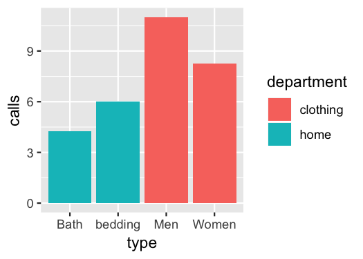

### Transforming data

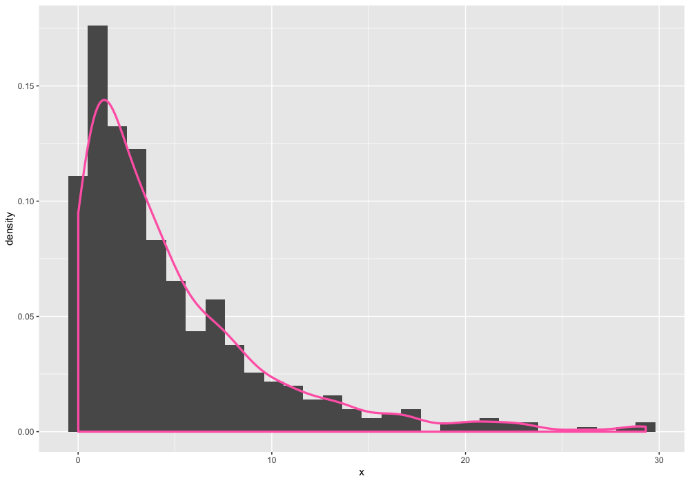

```r
ggplot(sdat, aes(x)) + geom_histogram(aes(y = ..density..))+
  geom_density(color='hotpink', size=1.1)
```

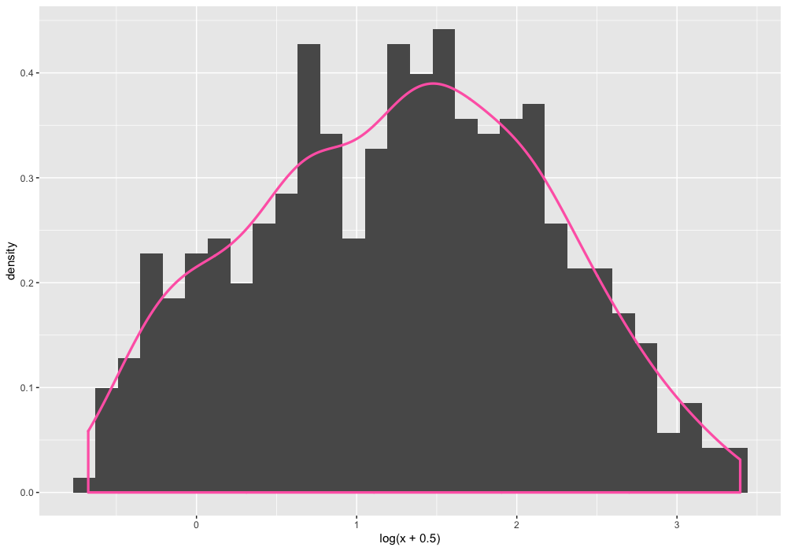

```r
ggplot(sdat, aes(log(x+0.5))) + geom_histogram(aes(y = ..density..))+
  geom_density(color='hotpink', size=1.1)
```

### Transforming data

- What does a log transformation do?

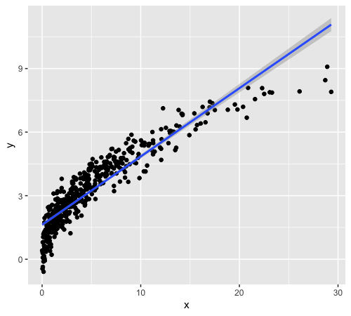

```r
ggplot(sdat, aes(x,y)) + geom_point() + geom_smooth(method="lm")
```

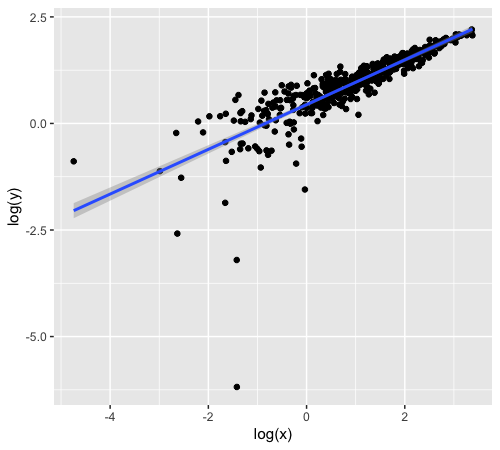

```r
ggplot(sdat, aes(log(x),log(y))) + geom_point() +
  geom_smooth(method="lm")
```

### Log transformation

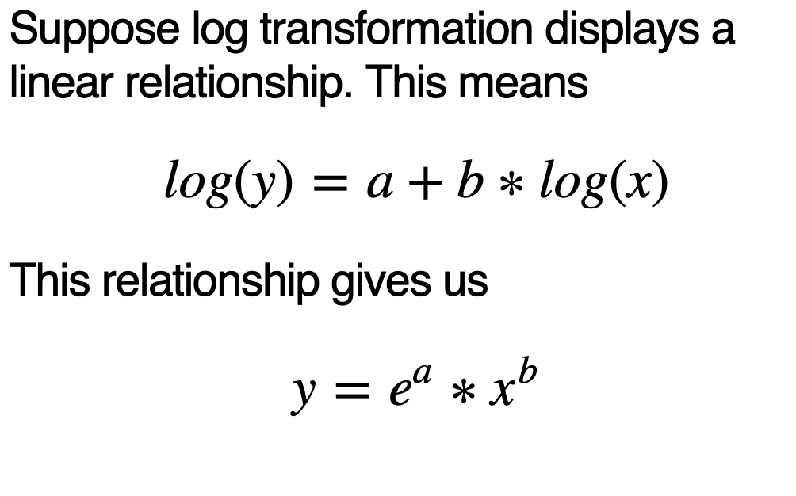

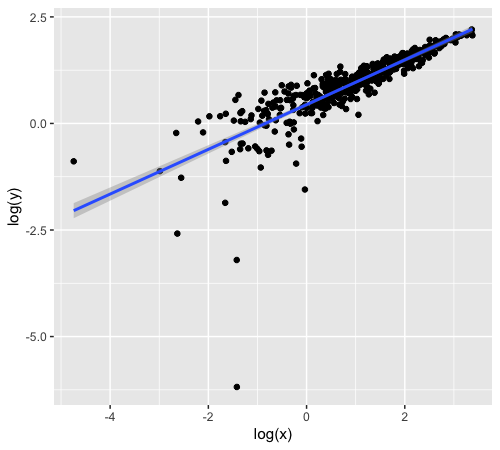

### Common transformations

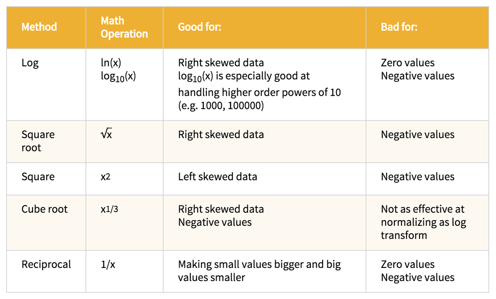

Source:  
https://infoactive.co/data-design/ch11.html

### Standardization of data

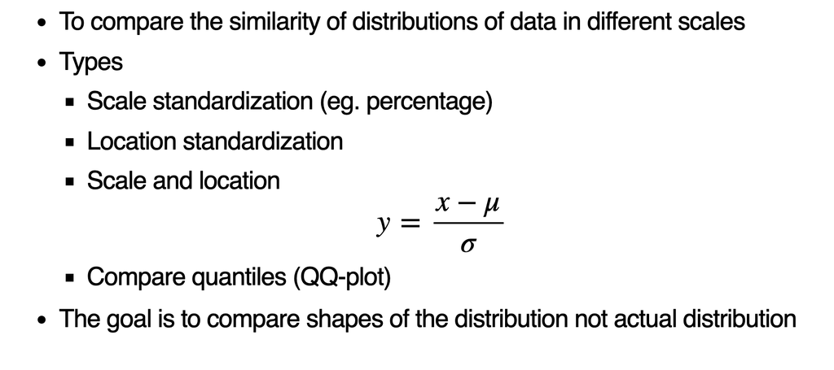

### Crime type vs state

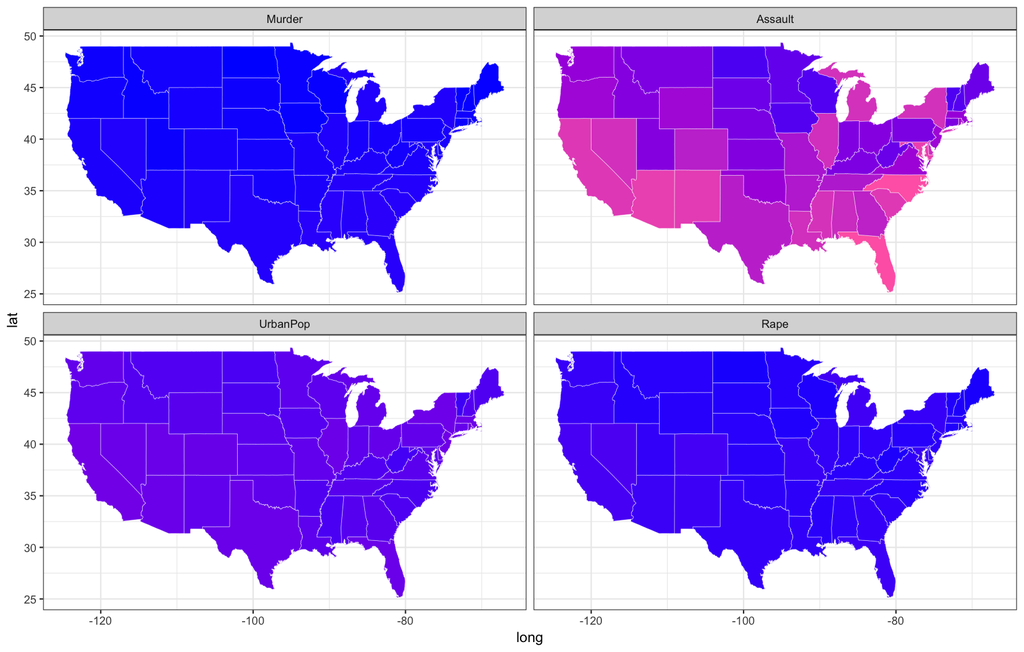

### After standardization

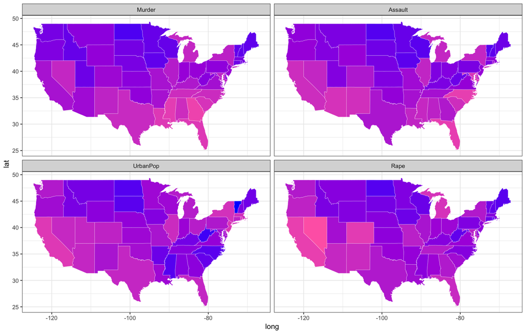

### Reading assignment and references

- Reshaping Data with the reshape Package  
  http://www.jstatsoft.org/v21/i12/paper
- Chapter 5, Modern Data Science with R by Baumer et al.